# Elements Of Data Visualization: Project 1

**By Alex Cortez, Adam Hernandex, and Alex Pearce**

**GitHub**: https://github.com/alexpearce92/DV_RProject1.git

In this project, the group familiarizes itself with git, knitr, ggplot, and basic SQL commands to create *interesting* plots of given data. Additionally, we create graphs usings the entire data set via a provided SQL query.

## We will first create our data frames.

#### We load the necessary libraries …

```r
library('RCurl')
library('ggplot2')
```

#### Then we query the database to generate our data frames

```r
source("../01 Data/create_data_frames.R", echo = TRUE)
```

```
##
## > customers.df <- data.frame(eval(parse(text = substring(getURL(URLencode("http://129.152.144.84:5001/rest/native/?query=\"select * from customers\"") .... [TRUNCATED]
##
## > items.df <- data.frame(eval(parse(text = substring(getURL(URLencode("http://129.152.144.84:5001/rest/native/?query=\"select * from items\""),
## +     .... [TRUNCATED]
##
## > order_details.df <- data.frame(eval(parse(text = substring(getURL(URLencode("http://129.152.144.84:5001/rest/native/?query=\"select * from order_det .... [TRUNCATED]
##
## > orders.df <- data.frame(eval(parse(text = substring(getURL(URLencode("http://129.152.144.84:5001/rest/native/?query=\"select * from orders\""),
## +   .... [TRUNCATED]
```

#### Here are the dataframes we just created

```r
head(customers.df)
```

```
##   CUSTOMER_ID CUSTOMER_FIRST_NAME CUSTOMER_LAST_NAME      CUSTOMER_ADDRESS
## 1           1               Korah             Blanca       1555 W Lane Ave
## 2           2                Yash            Randall 11 E Rancho Madera Rd
## 3           3           Johnathon          Millerton        60 Madison Ave
## 4           4             Mikayla             Damion      2021 K Street Nw
## 5           5             Kendall              Mayte 4775 E Miami River Rd
## 6           6             Kaitlin           Hostlery 3250 Spring Grove Ave
##   CUSTOMER_CITY CUSTOMER_STATE CUSTOMER_ZIP CUSTOMER_PHONE CUSTOMER_FAX
## 1      Columbus             OH        43221     6145554432   6145553920
## 2       Madison             WI        53707     2095551205   2095552262
## 3      New York             NY        10010     2125554800         NULL
## 4    Washington             DC        20006     2025555561         NULL
## 5        Cleves             OH        45002     5135553024         NULL
## 6    Cincinnati             OH        45225     8005552128   8005552640
```

```r
head(items.df)
```

```
##   ITEM_ID                                       TITLE
## 1       1                            Umami In Concert
## 2       2                             Race Car Sounds
## 3       3                       No Rest For The Weary
## 4       4 More Songs About Structures and Comestibles
## 5       5               On The Road With Burt Ruggles
## 6       6                            No Fixed Address
##                  ARTIST UNIT_PRICE
## 1                 Umami         17
## 2         The Ubernerds         13
## 3 No Rest For The Weary         16
## 4 No Rest For The Weary         17
## 5          Burt Ruggles         17
## 6 Sewed the Vest Pocket         16
```

```r
head(order_details.df)
```

```
##   ORDER_ID ITEM_ID ORDER_QTY
## 1      381       1         1
## 2      601       9         1
## 3      442       1         1
## 4      523       9         1
## 5      630       5         1
## 6      778       1         1
```

```r
head(orders.df)
```

```
##   ORDER_ID CUSTOMER_ID          ORDER_DATE        SHIPPED_DATE
## 1       19           1 2012-10-23 00:00:00 2012-10-28 00:00:00
## 2       29           8 2012-11-05 00:00:00 2012-11-11 00:00:00
## 3       32          11 2012-11-10 00:00:00 2012-11-13 00:00:00
## 4       45           2 2012-11-25 00:00:00 2012-11-30 00:00:00
## 5       70          10 2012-12-28 00:00:00 2013-01-07 00:00:00
## 6       89          22 2013-01-20 00:00:00 2013-01-22 00:00:00
```

## Now we create “interesting” graphs:

#### Below, we can see that most customers hail from California. How delightfully intriguing.

```
##
## > a <- ggplot(customers.df, aes(x = CUSTOMER_STATE,
## +     fill = CUSTOMER_STATE)) + geom_dotplot(na.rm = TRUE) + scale_y_continuous(name = "",
## +     .... [TRUNCATED]
##
## > suppressMessages(print(a))
```

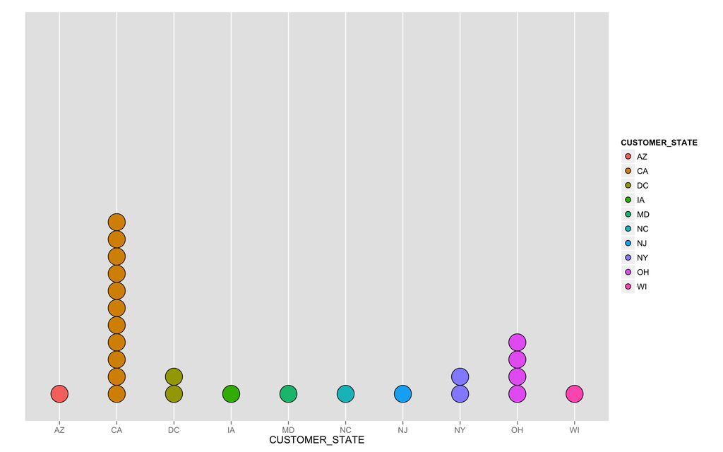

```r
source("../02 Visualizations/generate_plot_customers.R", echo = TRUE)
```

#### Now we look at the unit price an artist charges for an album. It appears that artists priced their albums at $17 with a much higher frequency than they priced their albums at $13. *Interesting*.

```
##
## > a <- ggplot(items.df, aes(x = UNIT_PRICE, fill = ARTIST)) +
## +     geom_bar(width = 1, color = "black", na.rm = TRUE) + scale_y_continuous("# Albums ..." ... [TRUNCATED]
##
## > suppressMessages(print(a))
```

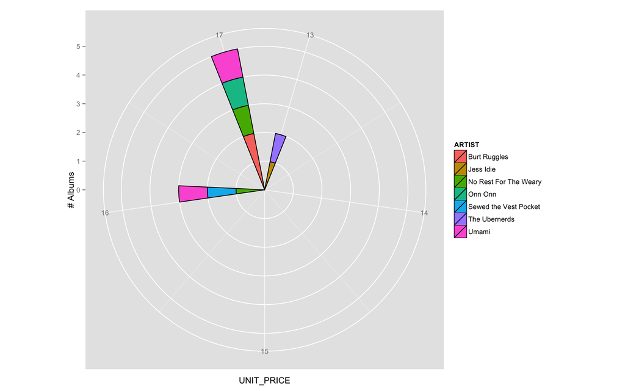

```r
source("../02 Visualizations/generate_plot_items.R", echo = TRUE)
```

#### Here we see which item has been asked for the most by customers. Item ID 1 seems to be the hottest commodity!

```
##
## > a <- ggplot(data = order_details.df, aes(x = ITEM_ID)) +
## +     geom_histogram(aes(fill = ..count..), na.rm = TRUE) + scale_fill_gradient("Count",
##  .... [TRUNCATED]
##
## > suppressMessages(print(a))
```

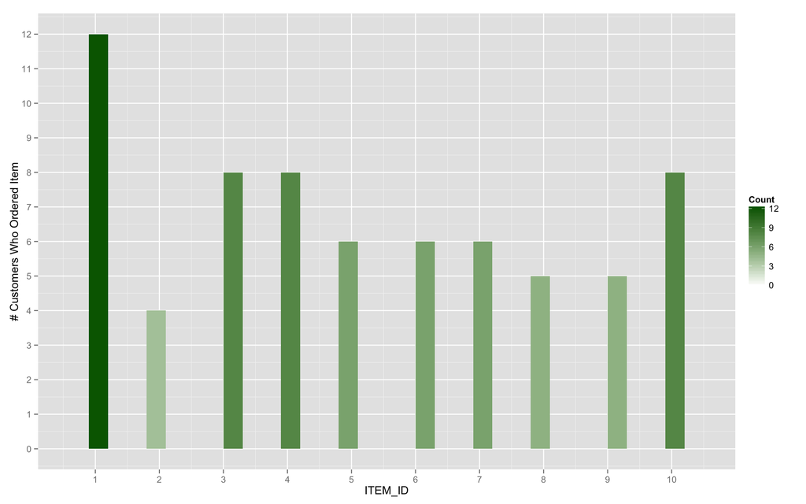

```r
source("../02 Visualizations/generate_plot_order_details.R", echo = TRUE)
```

#### Finally, we take a look at the number of orders per month. This was done by some initial data manipulation. It appears this company does poorly during September and October. Unfortunate.

We first subsetted the code to extract the months, generated a table of the frequency of occurance for each month, then applied ggplot() to our new data frame.

```
##
## > Months <- as.vector(as.integer(substr(orders.df$ORDER_DATE,
## +     6, 7)))
##
## > monthly_freq <- data.frame(table(Months))
##
## > a <- ggplot(monthly_freq, aes(x = Months, fill = Freq)) +
## +     geom_bar(width = 1, color = "black", na.rm = TRUE) + coord_polar() +
## +     scale_y .... [TRUNCATED]
##
## > suppressMessages(print(a))
```

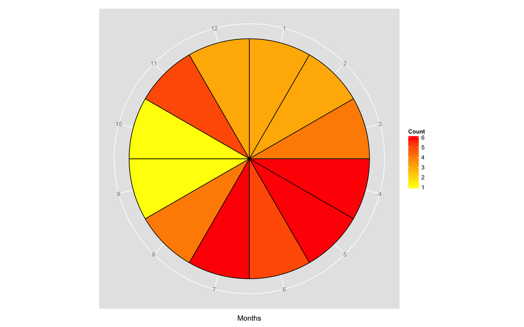

```r
source("../02 Visualizations/generate_plot_order_date.R", echo = TRUE)
```

## Now to recreate some other interesting graphs using several joins in the creation of our dataframe:

#### We first query the database with our SQL statement

```r
source("../01 Data/create_data_frame_joined.R", echo = TRUE)
```

```
##
## > set.df <- data.frame(eval(parse(text = substring(getURL(URLencode("http://129.152.144.84:5001/rest/native/?query=\"select * from orders o join custo .... [TRUNCATED]
```

#### Now let’s build some graphs

```
##
## > ggplot(set.df, aes(x = as.Date(ORDER_DATE, "%Y-%m-%d"),
## +     y = as.Date(SHIPPED_DATE, "%Y-%m-%d"))) + geom_point(aes(color = as.factor(UNIT_PRICE .... [TRUNCATED]
```

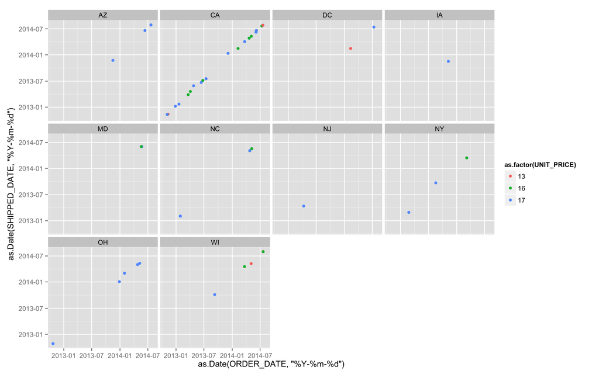

```r
source("../02 Visualizations/recreate_plot_1.R", echo = TRUE)
```

```
##
## > ggplot(set.df, aes(x = as.Date(ORDER_DATE, "%Y-%m-%d"),
## +     y = as.Date(SHIPPED_DATE, "%Y-%m-%d"))) + geom_point(aes(color = as.factor(TITLE)),
##  .... [TRUNCATED]
```

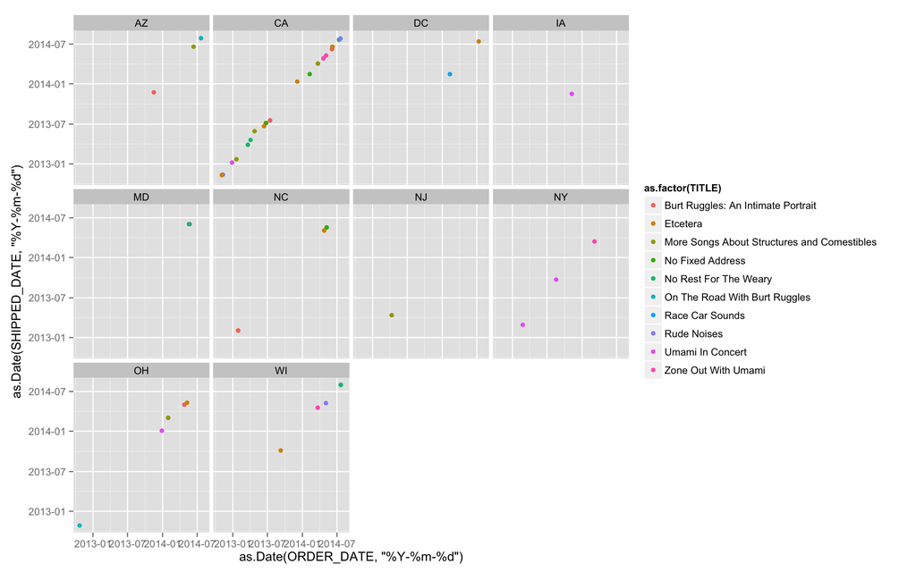

```r
source("../02 Visualizations/recreate_plot_2.R", echo = TRUE)
```

```
##
## > ggplot(set.df, aes(x = as.Date(ORDER_DATE, "%Y-%m-%d"),
## +     y = as.Date(SHIPPED_DATE, "%Y-%m-%d"))) + geom_point(aes(color = as.factor(ARTIST)),  .... [TRUNCATED]
```

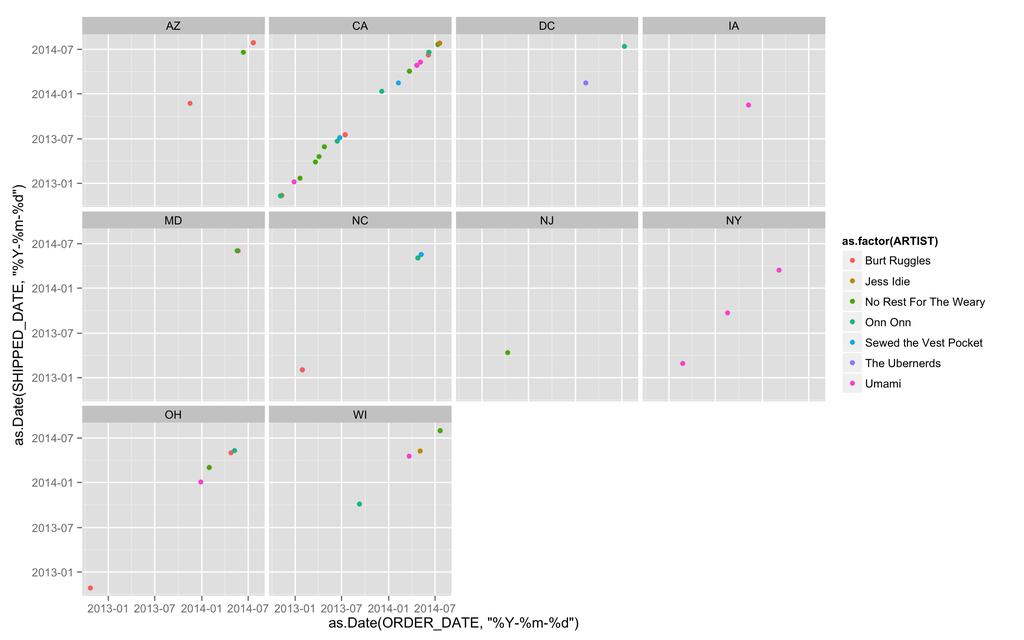

```r
source("../02 Visualizations/recreate_plot_3.R", echo = TRUE)
```